# API Specification

### Masks

Regions with no data will be filled by libCZI with the background color. There is therefore no way to tell between a pixel having the color of the background or being really background/invalid.

*A hacky way of figuring it out is to request the same data twice with different background colors.*

The real solution to this problem is by leveraging the mask data that exists in the CZI. Masks indicate regions with invalid or no data. There are two cases:  
- simple case: there is no subblock at aspecific location - advanced case: there is a subblock with mask data, indicating that there are parts with invalid pixels

However, there is no support (yet) for masks in libCZI. If we come to need it, it has to be implemented.

### Scenes

Scenes are not orthogonal to the other dimensions, they can be though of as “tags”. Thus, handling them as other dimensions will cause more problems than it would help.

In a nutshell: **The scene-index is not part of a plane-coordinate**

The arrangement below is possible:

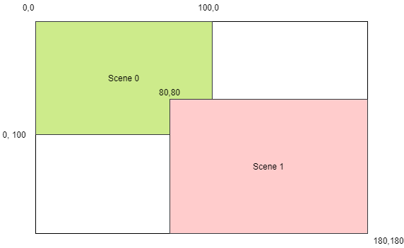

image info

Getting the dimensions of this CZI would show these scenes having the following bounding boxes:

**S0:** X=0, Y=0, W=100, H=100 **S1:** X=80, Y=80, W=100, H=100

For orthogonal dimensions, one can loop through them using the same ROI and not run into troubles. (Or am I missing something?) However, in the situation above, looping through scenes with the same ROI would produce bogus data:

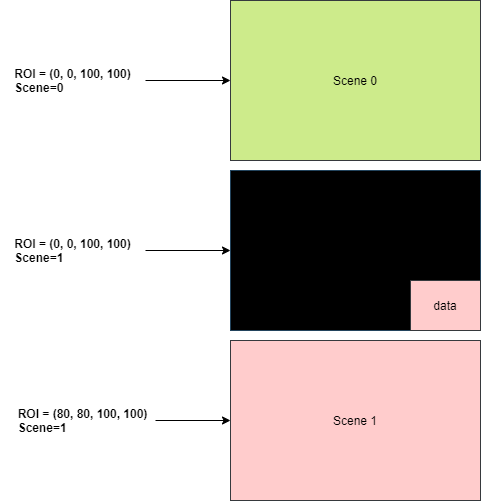

image info

So to avoid confusion we treat scenes differently. By having to deal with scenes separately, users will know that they’re not just another dimension.

#### Images with no scenes

Let’s say we have a single-channel CZI time series with no scenes:

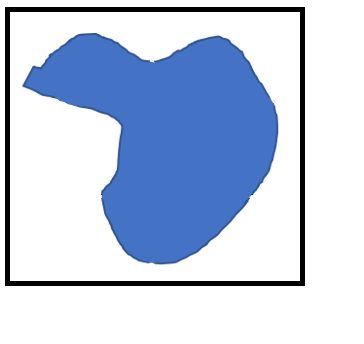

simple czi

**Get dimensions information:**

```python
total_bounding_box = get_total_bounding_box()
scene_bounding_rectangle = czi.get_scene_bounding_rectangle()
total_bounding_rectangle = czi.get_total_bounding_rectangle()

print(total_bounding_box)
# {'C': 0, 'T': (0, 5), 'X': (0, 400), 'Y': (0, 600)}
print(scene_bounding_rectangle)
# ''
print(total_bounding_rectangle)
# '(0, 0, 400, 600)'
```

**Default read (no ROI)**

```python
for t in t_enumerable:
    data = czi.read(plane = { 'T': t })
```

Returns:

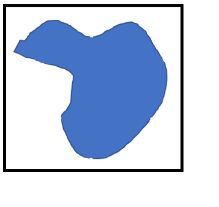

default read

**Specifying ROI:**

```python
for t in t_enumerable:
    roi = (0, 0, 200, 200)
    data = czi.read(roi=roi, plane = { 'T': t })
```

Returns:

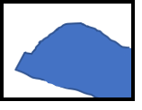

read at roi

#### Images with non-uniform scenes

Let’s say we have a single-channel time series and z-stack CZI with scenes:

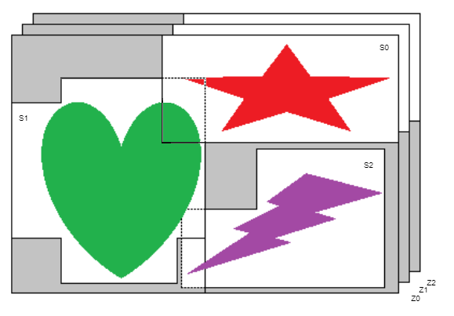

multi-scene czi

**Get dimensions information:**

```python
print(total_bounding_box)
# {'C': 0, 'T': (0, 5), 'Z': (0, 2), 'X': (0, 2000), 'Y': (0, 1400)}
```

In this case, scenes have different sizes/bounding boxes:

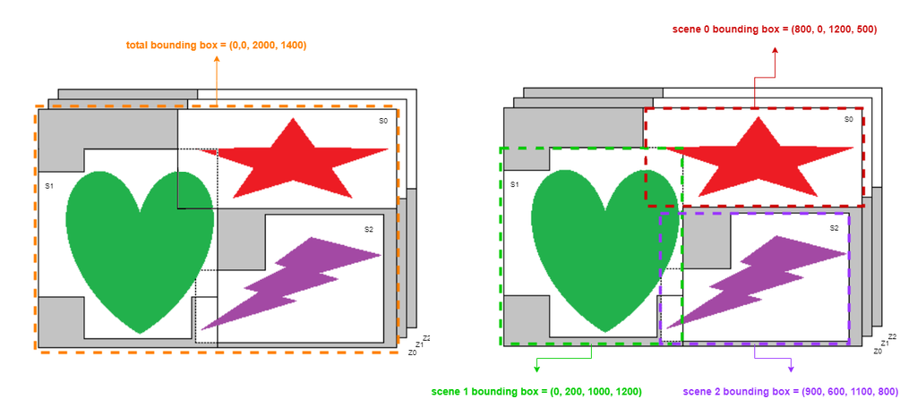

bounding boxes

```python
print(scene_bounding_rectangle)
# { 0: (800, 0, 1200, 500), 1: (0, 200, 1000, 1200), 2: (900, 600, 1100, 800)}
print(total_bounding_rectangle)
# { 0: (0, 0, 2000, 1400)}
```

**Default read (no ROI)**

If no scene is specified the call:

```python
data_all_scenes = czi.read()
```

Will have the following defaults: - ROI = total_bounding_rectangle = (0, 0, 2000, 1400) - Planes = { ‘C’: 0, ‘T’: 0, ‘Z’: 0 }

And return the following data:

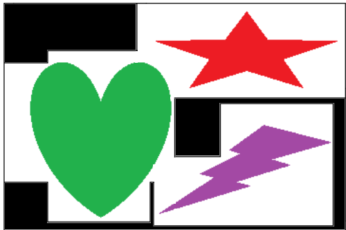

read no roi

If a scene is specified the call:

```python
data = czi.read(scene=1)
```

Will have the following defaults: - ROI = scene_bounding_rectangle[1] = (0, 200, 1000, 1200) - Planes = { ‘C’: 0, ‘T’: 0, ‘Z’: 0 }

And return the following data:

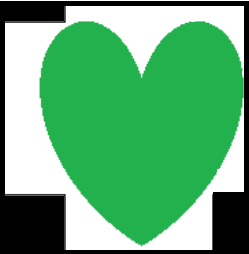

read no roi

**Specifying ROI:**

Getting data from a specific ROI works exactly as specified above. The user needs to keep in mind that the ROI can span across different scenes.

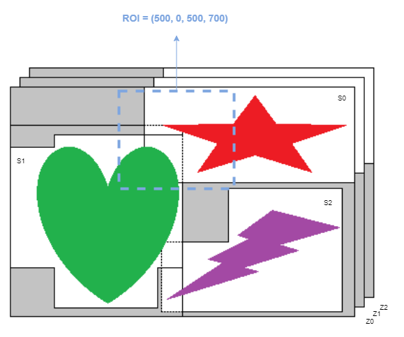

roi

```python
roi = (500, 0, 500, 700)

data_all_scenes = czi.read(roi=roi)
data_s1 = czi.read(roi=roi, scene=1)
```

Returns:

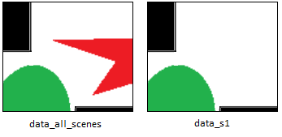

read at roi

#### Images with uniform scenes

Let’s consider an image with scenes of consistent shape, like a multi-well where each scene corresponds to a well.

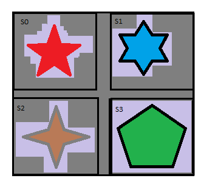

multi-well

The logic above is unaltered, but we will most likely not want to read data at ROIs spanning across multiple scenes. Instead, we would like to iterate over the scenes and get the scene/well data.

This can be done as follows:

```python
total_bounding_box = get_total_bounding_box()
scene_bounding_rectangle = czi.get_scene_bounding_rectangle()
total_bounding_rectangle = czi.get_total_bounding_rectangle()

print(total_bounding_box)
# {'X': (0, 1000), 'Y': (0, 1000)}
print(scene_bounding_rectangle)
# { 0: (0, 0, 400, 400), 1: (500, 0, 1000, 400), 2: (0, 500, 400, 1000), 3: (500, 500, 1000, 1000)}
print(total_bounding_rectangle)
# '(0, 0, 1000, 1000)'
```

```python
for s in scene_bounding_boxes.keys():
    roi = scene_bounding_boxes[s]
    data = czi.read(roi=roi)
```

This iteration returns the pixel data for each scene. There is no need to specify the scene_filter because the ROI is the scene bounding box and there are no overlapping scenes.

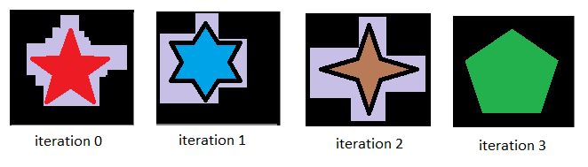

iteration results

### Handling Planes of Different Sizes

There are some CZIs where the size of the planes varies. Z-stacks acquired in the FiB-SEM are an example of this:

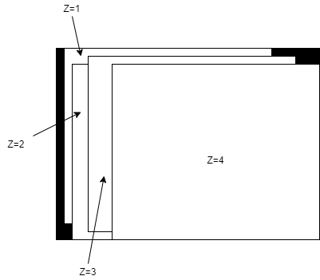

image info

This means that it’s possible to get zones with invalid data in different planes.

The user can nevertheless access the data normally, but the assumption that the planes are correctly stacked is not guaranteed.

**All planes live in a common pixel-coordinate system. And this pixel-coordinate-system gives the spatial position. Everything else is a matter of interpretation.**

The standard way of defining ROIs to cover a plane will lead situations like the one below, where accessing Z=4 starting with a ROI (0,0, w, h) produces a bitmap with invalid data.

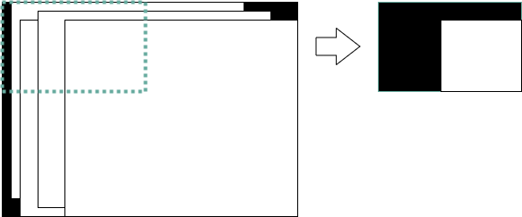

image info